# ReCell

### Background:

ReCell, a startup dealing with refurbished and used mobile devices is aiming to tap the potential in this market. They want to analyze the data provided and build a linear regression model to predict the price of a used phone and identify factors that significantly influence it.

### Objective:

The rising potential of refurbished and used mobile devices market fuels the need for an ML-based solution to develop a dynamic pricing strategy for used and refurbished smartphones

### Questions:

- 1/ What does the distribution of used phone prices look like?
- 2/ What percentage of the used phone market is dominated by Android devices?
- 3/ The amount of RAM is important for the smooth functioning of a phone. How does the amount of RAM vary with the brand?
- 4/ A large battery often increases a phone's weight, making it feel uncomfortable in the hands. How does the weight vary for  
  phones offering large batteries (more than 4500 mAh)?
- 5/ Bigger screens are desirable for entertainment purposes as they offer a better viewing experience. How many phones are available across different brands with a screen size larger than 6 inches?
- 6/ Budget phones nowadays offer great selfie cameras, allowing us to capture our favorite moments with loved ones. What is the distribution of budget phones offering greater than 8MP selfie cameras across brands?
- 7/ Which attributes are highly correlated with the used phone price?

### Data Description:

- 1. brand_name: Name of manufacturing brand
- 1. os: OS on which the phone runs
- 1. screen_size: Size of the screen in cm
- 1. 4g: Whether 4G is available or not
- 1. 5g: Whether 5G is available or not
- 1. main_camera_mp: Resolution of the rear camera in megapixels
- 1. selfie_camera_mp: Resolution of the front camera in megapixels
- 1. int_memory: Amount of internal memory (ROM) in GB
- 1. ram: Amount of RAM in GB
- 1. battery: Energy capacity of the phone battery in mAh
- 1. weight: Weight of the phone in grams
- 1. release_year: Year when the phone model was released
- 1. days_used: Number of days the used/refurbished phone has been used
- 1. new_price: Price of a new phone of the same model in euros
- 1. used_price: Price of the used/refurbished phone in euros

## Importing necessary libraries and data

```python
# Libraries to help with reading and manipulating data
import numpy as np
import pandas as pd

# Libraries to help with data visualization
import matplotlib.pyplot as plt

# Libraries to help with data visualization
import seaborn as sns
import matplotlib.pyplot as plt
%matplotlib inline
sns.set(style="darkgrid")



#supress warnings on depreceated features
import warnings
warnings.filterwarnings("ignore")

# to split the data into train and test
from sklearn.model_selection import train_test_split

# to build linear regression_model
from sklearn.linear_model import LinearRegression

# to check model performance
from sklearn.metrics import mean_absolute_error, mean_squared_error, r2_score

# to build linear regression_model using statsmodels
import statsmodels.api as sm
```

```python
pd.set_option('display.max_columns', None)

pd.set_option('display.max_rows', 200)
```

### Read the dataset

```python
# loading the dataset
data = pd.read_csv("used_phone_data.csv")
```

```python
df = data.copy()
```

```python
np.random.seed(1)
data.sample(200)
```

|  | brand_name | os | screen_size | 4g | 5g | main_camera_mp | selfie_camera_mp | int_memory | ram | battery | weight | release_year | days_used | new_price | used_price |
| --- | --- | --- | --- | --- | --- | --- | --- | --- | --- | --- | --- | --- | --- | --- | --- |
| 2501 | Samsung | Android | 13.49 | yes | no | 13.00 | 13.0 | 32.0 | 4.00 | 3600.0 | 181.00 | 2017 | 683 | 198.6800 | 79.47 |
| 2782 | Sony | Android | 13.81 | yes | no | NaN | 8.0 | 32.0 | 4.00 | 3300.0 | 156.00 | 2019 | 195 | 198.1500 | 149.10 |
| 605 | Others | Android | 12.70 | yes | no | 8.00 | 5.0 | 16.0 | 4.00 | 2400.0 | 137.00 | 2015 | 1048 | 161.4700 | 48.39 |
| 2923 | Vivo | Android | 19.37 | yes | no | 13.00 | 16.0 | 64.0 | 4.00 | 3260.0 | 149.30 | 2019 | 375 | 211.8800 | 138.31 |
| 941 | Others | Others | 5.72 | no | no | 0.30 | 0.3 | 32.0 | 0.25 | 820.0 | 90.00 | 2013 | 883 | 29.8100 | 8.92 |
| 1833 | LG | Android | 13.49 | no | no | 8.00 | 1.3 | 32.0 | 4.00 | 3140.0 | 161.00 | 2013 | 670 | 240.5400 | 96.18 |
| 671 | Apple | iOS | 14.92 | yes | no | 12.00 | 7.0 | 64.0 | 4.00 | 5493.0 | 48.00 | 2018 | 403 | 700.1500 | 350.08 |
| 1796 | LG | Android | 17.78 | yes | no | 5.00 | 0.3 | 16.0 | 4.00 | 4000.0 | 294.80 | 2014 | 708 | 189.3000 | 75.94 |
| 757 | Asus | Android | 13.49 | yes | no | 13.00 | 8.0 | 32.0 | 4.00 | 5000.0 | 181.00 | 2017 | 612 | 270.5000 | 108.13 |
| 3528 | Realme | Android | 15.72 | yes | no | NaN | 16.0 | 64.0 | 4.00 | 4035.0 | 184.00 | 2019 | 433 | 159.8850 | 80.00 |
| 3492 | Motorola | Android | 15.56 | yes | no | 13.00 | 8.0 | 64.0 | 4.00 | 4000.0 | 186.00 | 2019 | 228 | 118.9915 | 88.64 |
| 979 | Others | Android | 11.27 | yes | no | 8.00 | 0.3 | 32.0 | 4.00 | 2630.0 | 185.00 | 2014 | 1023 | 459.4700 | 137.82 |
| 1335 | Huawei | Android | 15.72 | yes | no | 13.00 | 8.0 | 128.0 | 4.00 | 3750.0 | 166.00 | 2018 | 399 | 398.8300 | 259.53 |
| 3279 | ZTE | Android | 10.95 | no | no | 5.00 | 0.3 | 16.0 | 4.00 | 2000.0 | 145.00 | 2013 | 808 | 100.0600 | 30.03 |
| 2761 | Others | Android | 13.81 | yes | no | 12.00 | 13.0 | 32.0 | 4.00 | 4000.0 | 175.00 | 2018 | 607 | 299.1200 | 119.71 |
| 1862 | Meizu | Android | 15.56 | yes | no | 13.00 | 20.0 | 128.0 | 4.00 | 3210.0 | 160.00 | 2018 | 653 | 199.5400 | 80.00 |
| 797 | Asus | Android | 15.24 | yes | no | 13.00 | 5.0 | 16.0 | 4.00 | 3000.0 | 190.00 | 2015 | 1014 | 309.2400 | 92.70 |
| 2625 | Samsung | Android | 13.81 | yes | no | 16.00 | 3.7 | 32.0 | 4.00 | 3220.0 | 176.00 | 2014 | 793 | 348.8700 | 139.67 |
| 2479 | Samsung | Android | 12.70 | yes | no | 8.00 | 5.0 | 16.0 | 4.00 | 2600.0 | 152.00 | 2018 | 452 | 150.4400 | 75.12 |
| 1156 | Honor | Android | 13.81 | yes | no | 13.00 | 8.0 | 32.0 | 4.00 | 3000.0 | 150.00 | 2018 | 663 | 118.6400 | 47.42 |
| 1143 | Honor | Android | 15.88 | yes | no | 13.00 | 25.0 | 256.0 | 4.00 | 4000.0 | 180.00 | 2018 | 410 | 570.6800 | 285.31 |
| 3568 | Alcatel | Android | 18.73 | yes | no | 13.00 | 5.0 | 32.0 | 3.00 | 4000.0 | 165.00 | 2020 | 201 | 92.6500 | 69.81 |
| 2629 | Samsung | Others | 5.08 | no | no | 8.00 | 2.0 | 16.0 | 4.00 | 300.0 | 67.00 | 2014 | 668 | 298.8000 | 119.56 |
| 2457 | Samsung | Android | 15.88 | yes | no | 12.00 | 25.0 | 128.0 | 4.00 | 4000.0 | 166.00 | 2019 | 377 | 350.2100 | 225.92 |
| 927 | Others | Others | 5.08 | no | no | 1.30 | 0.3 | 128.0 | 0.25 | 820.0 | 80.00 | 2013 | 905 | 20.9300 | 6.19 |
| 2150 | Nokia | Windows | 10.95 | yes | no | 5.00 | 1.6 | 32.0 | 4.00 | 1830.0 | 136.00 | 2014 | 809 | 99.7800 | 29.86 |
| 3229 | ZTE | Android | 12.70 | yes | no | 13.00 | 5.0 | 16.0 | 4.00 | 2500.0 | 135.00 | 2016 | 917 | 129.2000 | 38.78 |
| 203 | Xiaomi | Others | 14.92 | yes | no | 12.00 | 20.0 | 8.0 | 1.00 | 570.0 | 44.00 | 2019 | 267 | 148.6700 | 115.80 |
| 368 | Realme | Android | 16.03 | yes | no | NaN | 16.0 | 128.0 | 4.00 | 5000.0 | 199.00 | 2020 | 362 | 150.0200 | 98.10 |
| 2494 | Samsung | Android | 11.27 | yes | no | 5.00 | 2.0 | 32.0 | 4.00 | 2000.0 | 130.00 | 2017 | 670 | 119.2300 | 47.65 |

[output cut: 170 more lines]

```python
# check number of rows and columns
data.shape
```

```
(3571, 15)
```

- The dataset has 3571 rows and 15 columns.

### Check for any missing data

```python
#check for missing data
data.isna().sum().sort_values(ascending=False)
```

```
main_camera_mp      180
int_memory           10
ram                  10
weight                7
battery               6
selfie_camera_mp      2
brand_name            0
os                    0
screen_size           0
4g                    0
5g                    0
release_year          0
days_used             0
new_price             0
used_price            0
dtype: int64
```

- There are missing data mainly for **main_camera_mp** and few for int_memory, ram, weight, battery and very few on selfie_camera_mp.
- Further data analysis will need to be done for the best way to handle the missing data

### Check the info of the data

```python
data.info()
```

```
<class 'pandas.core.frame.DataFrame'>
RangeIndex: 3571 entries, 0 to 3570
Data columns (total 15 columns):
 #   Column            Non-Null Count  Dtype
---  ------            --------------  -----
 0   brand_name        3571 non-null   object
 1   os                3571 non-null   object
 2   screen_size       3571 non-null   float64
 3   4g                3571 non-null   object
 4   5g                3571 non-null   object
 5   main_camera_mp    3391 non-null   float64
 6   selfie_camera_mp  3569 non-null   float64
 7   int_memory        3561 non-null   float64
 8   ram               3561 non-null   float64
 9   battery           3565 non-null   float64
 10  weight            3564 non-null   float64
 11  release_year      3571 non-null   int64
 12  days_used         3571 non-null   int64
 13  new_price         3571 non-null   float64
 14  used_price        3571 non-null   float64
dtypes: float64(9), int64(2), object(4)
memory usage: 418.6+ KB
```

- brand_name and os are of object
- 4g and 5g are also object , This can be converted to categorical
- release_year is int64 , this needs to be converted to date type

### EDA

```python
for col in ['4g', '5g', 'brand_name', 'os']:
    data[col] = data[col].astype('category')
```

```python
data.info()
```

```
<class 'pandas.core.frame.DataFrame'>
RangeIndex: 3571 entries, 0 to 3570
Data columns (total 15 columns):
 #   Column            Non-Null Count  Dtype
---  ------            --------------  -----
 0   brand_name        3571 non-null   category
 1   os                3571 non-null   category
 2   screen_size       3571 non-null   float64
 3   4g                3571 non-null   category
 4   5g                3571 non-null   category
 5   main_camera_mp    3391 non-null   float64
 6   selfie_camera_mp  3569 non-null   float64
 7   int_memory        3561 non-null   float64
 8   ram               3561 non-null   float64
 9   battery           3565 non-null   float64
 10  weight            3564 non-null   float64
 11  release_year      3571 non-null   int64
 12  days_used         3571 non-null   int64
 13  new_price         3571 non-null   float64
 14  used_price        3571 non-null   float64
dtypes: category(4), float64(9), int64(2)
memory usage: 322.7 KB
```

**4g . 5g , os and brand_name are now category**

```python
data[['4g', '5g']].nunique()
```

```
4g    2
5g    2
dtype: int64
```

##### Check the different values of 4g

```python
pd.unique(data['4g'].values)
```

```
['yes', 'no']
Categories (2, object): ['yes', 'no']
```

##### Check the different values of 5g

```python
pd.unique(data['5g'].values)
```

```
['no', 'yes']
Categories (2, object): ['no', 'yes']
```

```python
data[['brand_name', 'os']].nunique()
```

```
brand_name    34
os             4
dtype: int64
```

```python
data['release_year']
```

```
0       2020
1       2020
2       2020
3       2020
4       2020
        ...
3566    2019
3567    2018
3568    2020
3569    2020
3570    2020
Name: release_year, Length: 3571, dtype: int64
```

```python
pd.to_datetime(data['release_year']).dt.year
```

```
0       1970
1       1970
2       1970
3       1970
4       1970
        ...
3566    1970
3567    1970
3568    1970
3569    1970
3570    1970
Name: release_year, Length: 3571, dtype: int64
```

##### Check the different values of brand_name

```python
data.brand_name.value_counts()
```

```
Others        509
Samsung       364
Huawei        264
LG            212
Lenovo        172
ZTE           141
Xiaomi        134
Oppo          129
Asus          126
Alcatel       125
Nokia         121
Micromax      120
Honor         118
Vivo          117
HTC           110
Motorola      110
Sony           88
Meizu          62
Apple          59
Gionee         56
Acer           51
XOLO           49
Panasonic      47
Realme         41
Celkon         37
Lava           36
Karbonn        30
Spice          30
Microsoft      22
OnePlus        22
Coolpad        22
BlackBerry     22
Google         15
Infinix        10
Name: brand_name, dtype: int64
```

- Observation: There is value of 'others'
- Samsung, Huawei and LG are the top brands in the data set

##### Check the different values of os

```python
pd.unique(data['os'].values)
```

```
['Android', 'Others', 'iOS', 'Windows']
Categories (4, object): ['Android', 'Others', 'iOS', 'Windows']
```

#### Change the data type to be categorical

```python
for col in ['4g', '5g', 'brand_name', 'os']:
    data[col] = data[col].astype('category')
```

```python
data.info()
```

```
<class 'pandas.core.frame.DataFrame'>
RangeIndex: 3571 entries, 0 to 3570
Data columns (total 15 columns):
 #   Column            Non-Null Count  Dtype
---  ------            --------------  -----
 0   brand_name        3571 non-null   category
 1   os                3571 non-null   category
 2   screen_size       3571 non-null   float64
 3   4g                3571 non-null   category
 4   5g                3571 non-null   category
 5   main_camera_mp    3391 non-null   float64
 6   selfie_camera_mp  3569 non-null   float64
 7   int_memory        3561 non-null   float64
 8   ram               3561 non-null   float64
 9   battery           3565 non-null   float64
 10  weight            3564 non-null   float64
 11  release_year      3571 non-null   int64
 12  days_used         3571 non-null   int64
 13  new_price         3571 non-null   float64
 14  used_price        3571 non-null   float64
dtypes: category(4), float64(9), int64(2)
memory usage: 322.7 KB
```

#### Get a summary of the data

```python
data.describe(include='all').T
```

|  | count | unique | top | freq | mean | std | min | 25% | 50% | 75% | max |
| --- | --- | --- | --- | --- | --- | --- | --- | --- | --- | --- | --- |
| brand_name | 3571 | 34 | Others | 509 | NaN | NaN | NaN | NaN | NaN | NaN | NaN |
| os | 3571 | 4 | Android | 3246 | NaN | NaN | NaN | NaN | NaN | NaN | NaN |
| screen_size | 3571.0 | NaN | NaN | NaN | 14.803892 | 5.153092 | 2.7 | 12.7 | 13.49 | 16.51 | 46.36 |
| 4g | 3571 | 2 | yes | 2359 | NaN | NaN | NaN | NaN | NaN | NaN | NaN |
| 5g | 3571 | 2 | no | 3419 | NaN | NaN | NaN | NaN | NaN | NaN | NaN |
| main_camera_mp | 3391.0 | NaN | NaN | NaN | 9.400454 | 4.818396 | 0.08 | 5.0 | 8.0 | 13.0 | 48.0 |
| selfie_camera_mp | 3569.0 | NaN | NaN | NaN | 6.547352 | 6.879359 | 0.3 | 2.0 | 5.0 | 8.0 | 32.0 |
| int_memory | 3561.0 | NaN | NaN | NaN | 54.532607 | 84.696246 | 0.005 | 16.0 | 32.0 | 64.0 | 1024.0 |
| ram | 3561.0 | NaN | NaN | NaN | 4.056962 | 1.391844 | 0.03 | 4.0 | 4.0 | 4.0 | 16.0 |
| battery | 3565.0 | NaN | NaN | NaN | 3067.225666 | 1364.206665 | 80.0 | 2100.0 | 3000.0 | 4000.0 | 12000.0 |
| weight | 3564.0 | NaN | NaN | NaN | 179.424285 | 90.280856 | 23.0 | 140.0 | 159.0 | 184.0 | 950.0 |
| release_year | 3571.0 | NaN | NaN | NaN | 2015.964996 | 2.291784 | 2013.0 | 2014.0 | 2016.0 | 2018.0 | 2020.0 |
| days_used | 3571.0 | NaN | NaN | NaN | 675.391487 | 248.640972 | 91.0 | 536.0 | 690.0 | 872.0 | 1094.0 |
| new_price | 3571.0 | NaN | NaN | NaN | 237.389037 | 197.545581 | 9.13 | 120.13 | 189.8 | 291.935 | 2560.2 |
| used_price | 3571.0 | NaN | NaN | NaN | 109.880277 | 121.501226 | 2.51 | 45.205 | 75.53 | 126.0 | 1916.54 |

```python
data.describe(include=['category']).T
```

|  | count | unique | top | freq |
| --- | --- | --- | --- | --- |
| brand_name | 3571 | 34 | Others | 509 |
| os | 3571 | 4 | Android | 3246 |
| 4g | 3571 | 2 | yes | 2359 |
| 5g | 3571 | 2 | no | 3419 |

#### Functions for plotting

```python
# function to plot a boxplot and a histogram along the same scale.

# import the library for labelling
import matplotlib.patheffects as path_effects

# import the library for labelling
import matplotlib.patheffects as path_effects

def add_median_labels(ax):
    lines = ax.get_lines()
    # determine number of lines per box (this varies with/without fliers)
    boxes = [c for c in ax.get_children() if type(c).__name__ == 'PathPatch']
    lines_per_box = int(len(lines) / len(boxes))
    # iterate over median lines
    for median in lines[4:len(lines):lines_per_box]:
        # display median value at center of median line
        x, y = (data.mean() for data in median.get_data())
        # choose value depending on horizontal or vertical plot orientation
        value = x if (median.get_xdata()[1]-median.get_xdata()[0]) == 0 else y
        text = ax.text(x, y, f'{value:.1f}', ha='center', va='center',
                       fontweight='bold', color='white', bbox=dict(facecolor='black'),size=15)
        # create median-colored border around white text for contrast
        text.set_path_effects([
            path_effects.Stroke(linewidth=3, foreground=median.get_color()),
            path_effects.Normal(),
        ])

def box_and_histogram(column,  figsize=(10,10), bins = None):
    """ Boxplot and histogram together, with median labels on boxplot
    df_series: dataframe column
    figsize: size of fig (default (9,8))
    bins: number of bins (default None / auto)
    color of mean is green and median is black
    """
    f2, (ax_box2, ax_hist2) = plt.subplots(nrows = 2, # Number of rows of the subplot grid= 2
                                           sharex = True, # x-axis will be shared among all subplots
                                           gridspec_kw = {"height_ratios": (.25, .75)},
                                           figsize = figsize
                                            ) # creating the 2 subplots
    box_plot = sns.boxplot(column, ax=ax_box2,showmeans=True, color='red')
    add_median_labels(box_plot.axes)


    sns.distplot(column, kde=F, bins=bins) if bins else sns.distplot(column, kde=True, ) # For histogram
    ax_hist2.axvline(np.mean(column), color='g', linestyle='--') # Add mean to the histogram
    ax_hist2.axvline(np.median(column), color='black', linestyle='-') # Add median to the histogram
```

### EDA

#### Univariate Analysis

```python
# function to create labeled barplots


def labeled_barplot(data, feature, perc=False, n=None):
    """
    Barplot with percentage at the top

    data: dataframe
    feature: dataframe column
    perc: whether to display percentages instead of count (default is False)
    n: displays the top n category levels (default is None, i.e., display all levels)
    """

    total = len(data[feature])  # length of the column
    count = data[feature].nunique()
    if n is None:
        plt.figure(figsize=(count + 1, 5))
    else:
        plt.figure(figsize=(n + 1, 5))

    plt.xticks(rotation=90, fontsize=15)
    ax = sns.countplot(
        data=data,
        x=feature,
        palette="RdYlBu",
        order=data[feature].value_counts().index


    )

    for p in ax.patches:
        if perc == True:
            label = "{:.1f}%".format(
                100 * p.get_height() / total
            )  # percentage of each class of the category
        else:
            label = p.get_height()  # count of each level of the category

        x = p.get_x() + p.get_width() / 2  # width of the plot
        y = p.get_height()  # height of the plot

        ax.annotate(
            label,
            (x, y),
            ha="center",
            va="center",
            size=12,
            xytext=(0, 5),
            textcoords="offset points",
        )  # annotate the percentage

    plt.show()  # show the plot
```

```
 Plot for 4g
```

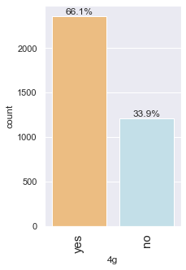

```
 Plot for 5g
```

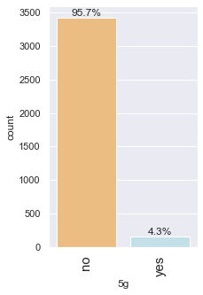

```
 Plot for os
```

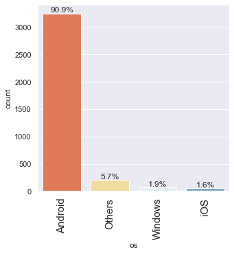

```python
for col in ['4g', '5g', 'os']:
    print(' Plot for {}'.format(col))
    labeled_barplot(data, col, True)
```

- Android has almost 91% share
- Most of the phones have 4G
- Most of the phones do not have 5G

#### Distribution of phones across brands

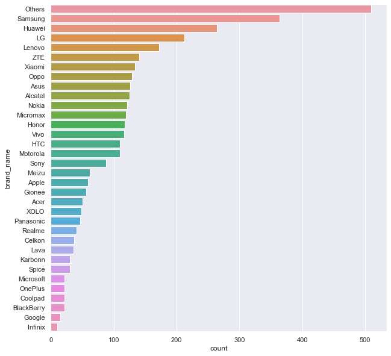

```python
#sns.set(style="whitegrid")
plt.figure(figsize=(10, 10))
sns.countplot(y=data['brand_name'], order = data['brand_name'].value_counts().index);
```

**Samsung, Huawei and LG are top 3 individual brands**

```python
numeric_cols = data.select_dtypes(['int64']).columns
numeric_cols
```

```
Index(['release_year', 'days_used'], dtype='object')
```

```python
float_cols = data.select_dtypes(['float64']).columns
float_cols
```

```
Index(['screen_size', 'main_camera_mp', 'selfie_camera_mp', 'int_memory',
       'ram', 'battery', 'weight', 'new_price', 'used_price'],
      dtype='object')
```

##### Plots for screen_size

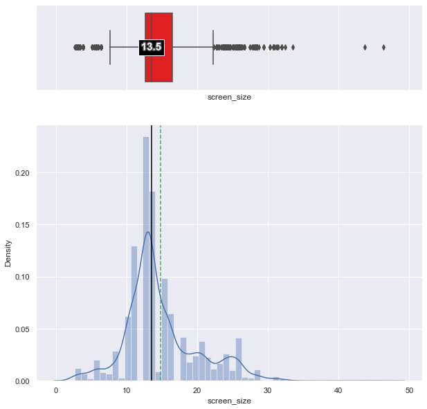

```python
# Let's visualize the data for ['screen_size']
screen_size =  ['screen_size']
for col in screen_size:
    box_and_histogram(data[col])
```

**Observation**

- The data has 3 peaks
- Most phones have screen size of 12.5, ~13.5 followed by ~22 cms

#### Plots for 'main_camera_mp', 'selfie_camera_mp'

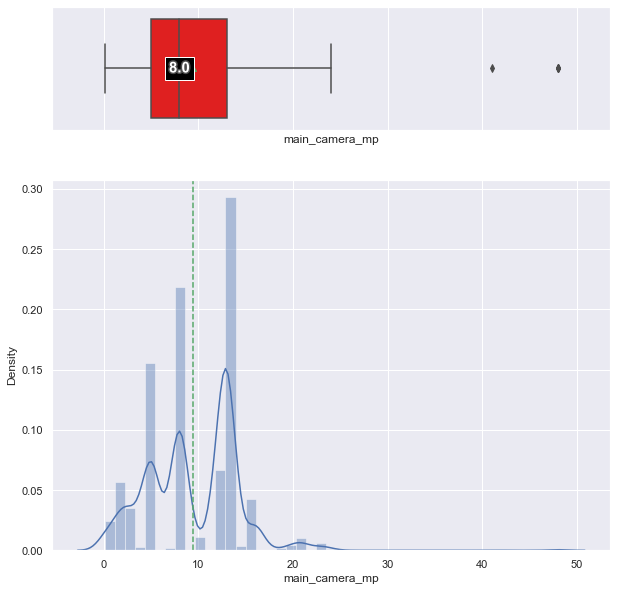

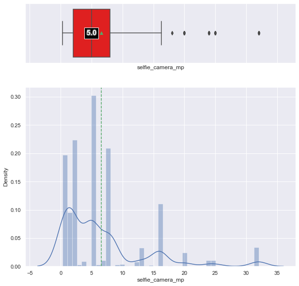

```python
# Let's visualize the data for ['main_camera_mp', 'selfie_camera_mp']
camera_cols =  ['main_camera_mp', 'selfie_camera_mp']
for col in camera_cols:
    box_and_histogram(data[col])
```

**Observation**

- main_camera_mp: The data has 3 to 4 peaks
- selfie_camera_mp : There are several peaks, indication wide variety

##### Plots for 'int_memory','ram'

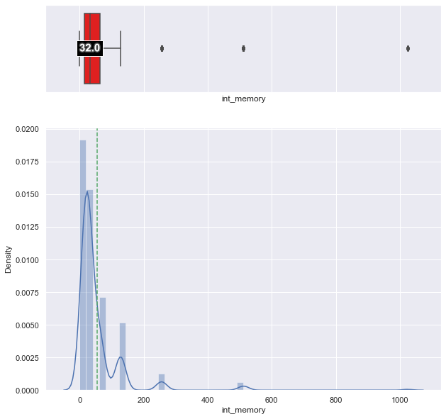

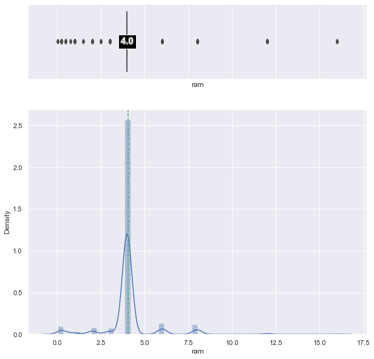

```python
# Let's visualize the data for ['int_memory','ram']
int_memory_and_ram =  ['int_memory','ram']
for col in int_memory_and_ram:
    box_and_histogram(data[col])
```

**Observation**

- int_memory : Data is distribute around few values, indicating not many variations
- ram : Almost all phones have similar amont of Ram

##### Plots for 'battery', 'weight'

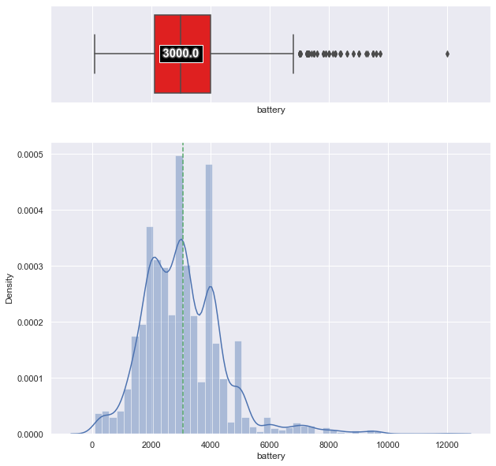

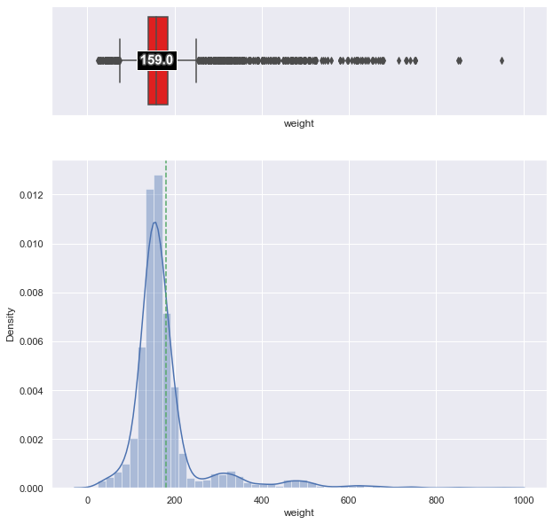

```python
# Let's visualize the data for ['battery', 'weight']
clos_to_display =  ['battery', 'weight']
for col in clos_to_display:
    box_and_histogram(data[col])
```

**Observation**

- battery : Data is around the mean
- weight :Most of Data is around the mean

##### Plots for 'release_year' and 'days_used'

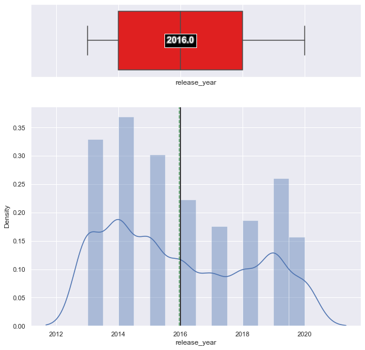

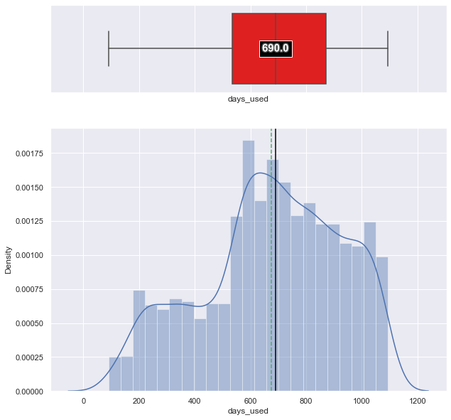

```python
# Let's visualize the data for ['release_year', 'days_used']
release_year_and_days_used = ['release_year', 'days_used']
for col in release_year_and_days_used:
    box_and_histogram(data[col])
```

**Observataion**

**Plots for new_price and used_price**

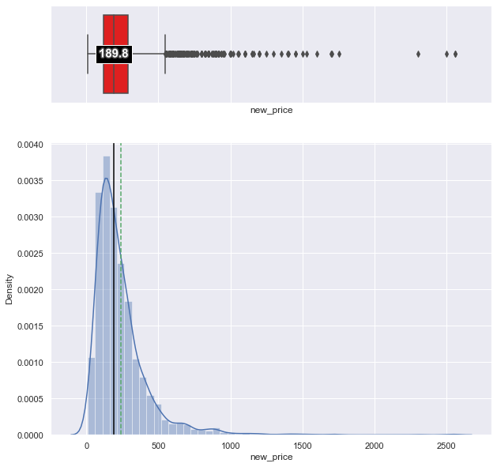

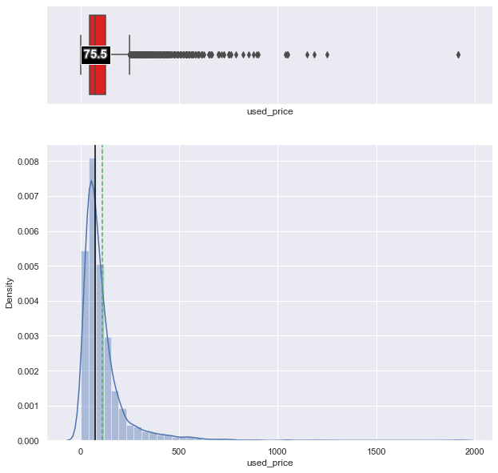

```python
# Let's visualize the data for ['new_price', 'used_price']
price_cols =['new_price', 'used_price']
for col in price_cols:
    box_and_histogram(data[col])
```

**Observation**

#### Bivariate Analysis

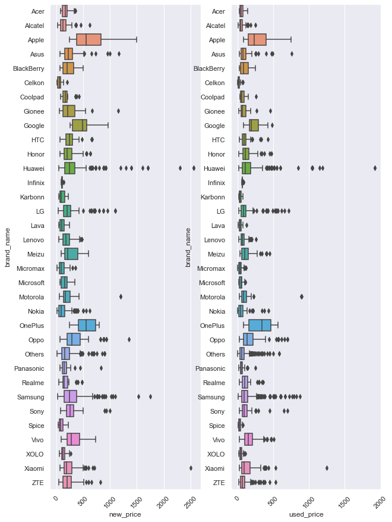

```python
plt.rcParams["figure.figsize"] = (10,15)


plt.subplot(1, 2, 1)
sns.boxplot(data=data, x="new_price", y="brand_name")
plt.xticks(rotation=45)

plt.subplot(1, 2, 2)
sns.boxplot(data=data, x="used_price", y="brand_name")
plt.xticks(rotation=45)


plt.show()
```

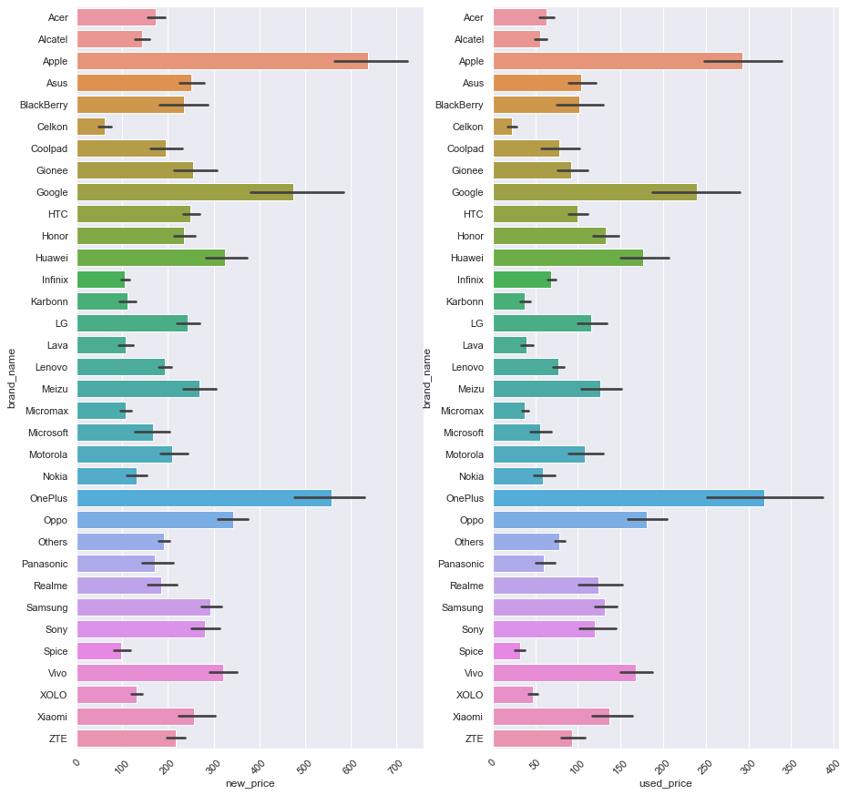

```python
plt.rcParams["figure.figsize"] = (15,15)

plt.subplot(1, 2, 1)
sns.barplot(data=data, x="new_price", y="brand_name")
plt.xticks(rotation=45)

plt.subplot(1, 2, 2)
sns.barplot(data=data, x="used_price", y="brand_name")
plt.xticks(rotation=45)


plt.show()
```

**Observation**

- OnePlus, Apple, Google have highest mean used_price

#### brand_name Vs used_price

```python
data.groupby('brand_name')['used_price'].mean().sort_values(ascending = False)
```

```
brand_name
OnePlus       318.515909
Apple         293.228814
Google        239.211333
Oppo          180.845271
Huawei        176.256894
Vivo          168.190855
Xiaomi        137.465149
Honor         132.285932
Samsung       132.083462
Meizu         126.515484
Realme        124.169024
Sony          119.886136
LG            115.853726
Motorola      107.695636
Asus          103.764921
BlackBerry    102.039091
HTC            99.626000
ZTE            93.621489
Gionee         91.881964
Others         78.492102
Coolpad        77.928182
Lenovo         77.147500
Infinix        68.979000
Acer           63.798431
Panasonic      60.302979
Nokia          59.393719
Alcatel        55.326080
Microsoft      55.316818
XOLO           47.340204
Lava           40.112778
Micromax       38.134417
Karbonn        38.069333
Spice          32.299667
Celkon         22.648378
Name: used_price, dtype: float64
```

#### os Vs used_price

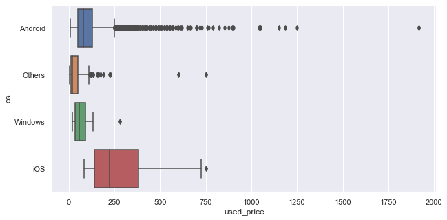

```python
plt.figure(figsize=(10, 5))
sns.boxplot(data['used_price'], data['os']);
```

**Observation**

- Among the brands 'iOS' has the highest priced phones
- Android phones have large outliers , indication wide variety of phones

#### battery Vs used_price

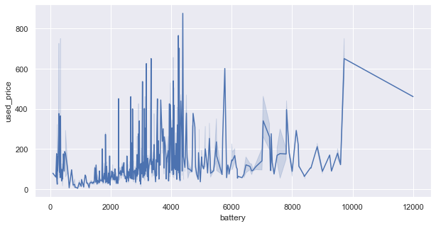

```python
plt.figure(figsize=(10, 5))
sns.lineplot(y=data['used_price'], x=data['battery']);
```

**Observation**

- There is no clear pattern

#### Weight Vs used_price

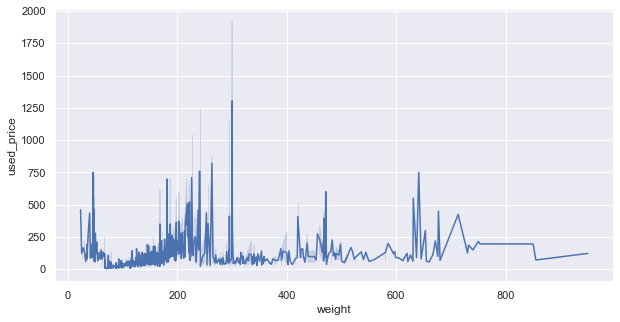

```python
plt.figure(figsize=(10, 5))
sns.lineplot(y=data['used_price'], x=data['weight']);
```

**Observation**

- Similar to battery, there is no clear pattern

#### ram Vs used_price

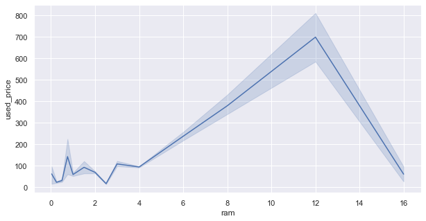

```python
plt.figure(figsize=(10, 5))
sns.lineplot(y=data['used_price'], x=data['ram']);
```

**Observation**

- Increase in ram leads to higher used_price, but interesting that price decreases after ram size reached 12 GB

#### int_memory Vs used_price

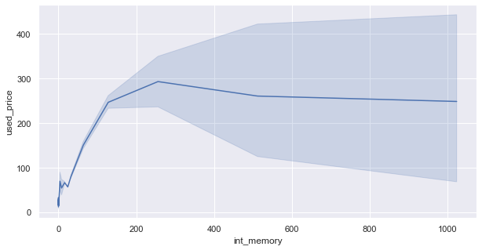

```python
plt.figure(figsize=(10, 5))
sns.lineplot(y=data['used_price'], x=data['int_memory']);
```

**Observation**

- There is a increase of price with increase of int_memory, but the price flattens after 250 GB

#### 5g Vs used_price

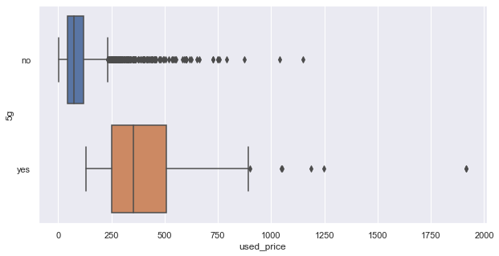

```python
plt.figure(figsize=(10, 5))
sns.boxplot(data['used_price'], data['5g']);
```

**Observation**

- 5G phones are in general higher priced

#### 4G Vs used_price

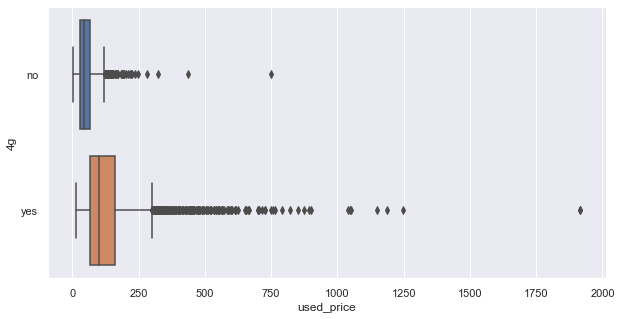

```python
plt.figure(figsize=(10, 5))
sns.boxplot(data['used_price'], data['4g']);
```

**Observation**

#### days_used Vs used_price

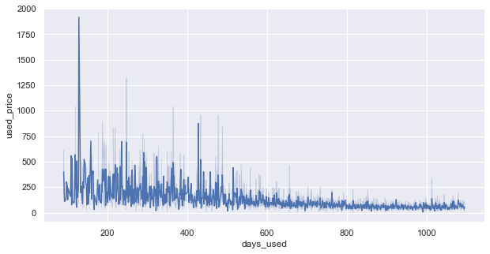

```python
plt.figure(figsize=(10, 5))
sns.lineplot(y=data['used_price'], x=data['days_used']);
```

**Observation**

- No clear trend, but phoes use less than 200 days have a higher price

```python
#### release_year Vs used_price
```

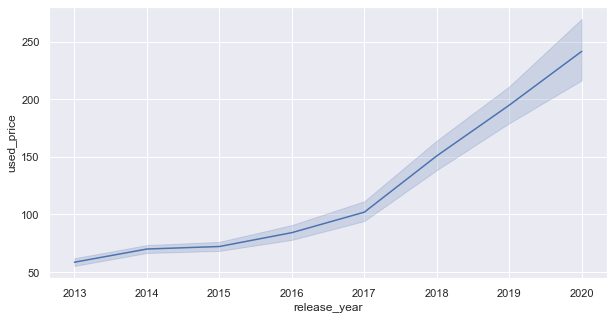

```python
plt.figure(figsize=(10, 5))
sns.lineplot(y=data['used_price'], x=data['release_year']);
```

**Observation**

- The latest the release_year the higher the price

#### screen_size Vs used_price

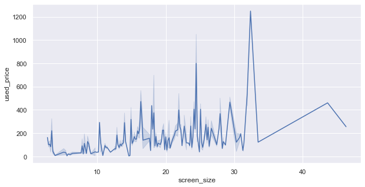

```python
plt.figure(figsize=(10, 5))
sns.lineplot(y=data['used_price'], x=data['screen_size']);
```

**Observation**

- The bigger the screen size higher the price, there are some outliers

```python
# Let us plot the corelation of numeric columns
numeric_columns = data.select_dtypes(exclude = ['category']).columns
numeric_columns
```

```
Index(['screen_size', 'main_camera_mp', 'selfie_camera_mp', 'int_memory',
       'ram', 'battery', 'weight', 'release_year', 'days_used', 'new_price',
       'used_price'],
      dtype='object')
```

```python
# Check for correlation among numerical variables
num_var = ['screen_size', 'main_camera_mp', 'selfie_camera_mp', 'int_memory',
       'ram', 'battery', 'weight', 'release_year', 'days_used', 'new_price',
       'used_price']

corr = data[num_var].corr()
```

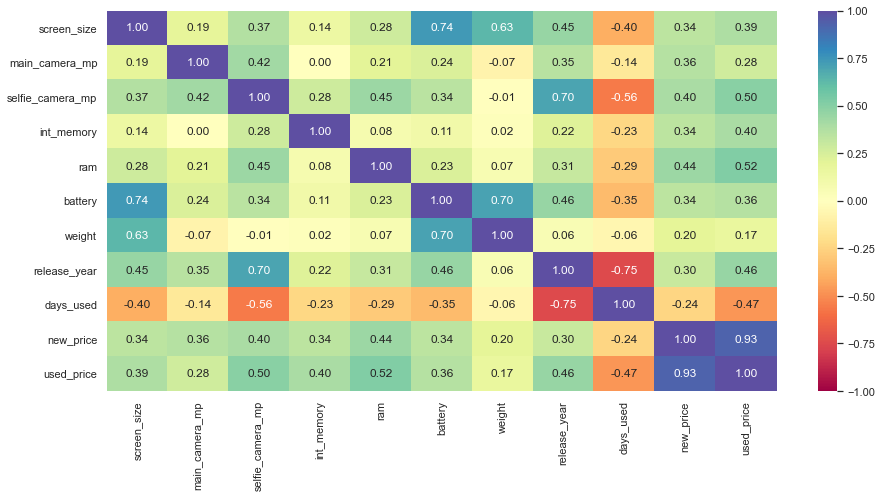

```python
# correlation heatmap
plt.figure(figsize=(15, 7))
sns.heatmap(
    df[num_var].corr(),
    annot=True,
    vmin=-1,
    vmax=1,
    fmt=".2f",
    cmap="Spectral",
)
plt.show()
```

**Observation**

- Battery and weight are corelated , as expected.
- Screen_size and battery are corelated , indicating large screen size needs large batteries.
- selfie_camera_mp and release_year are corelated , indicating new models have better selfie cameras.
- Days_used and used_price are negatively corelated.

###### Let us check possible Multicollinearity

```python
poss_Multicollinearity = ['main_camera_mp', 'selfie_camera_mp', 'int_memory',
       'ram', 'used_price']
```

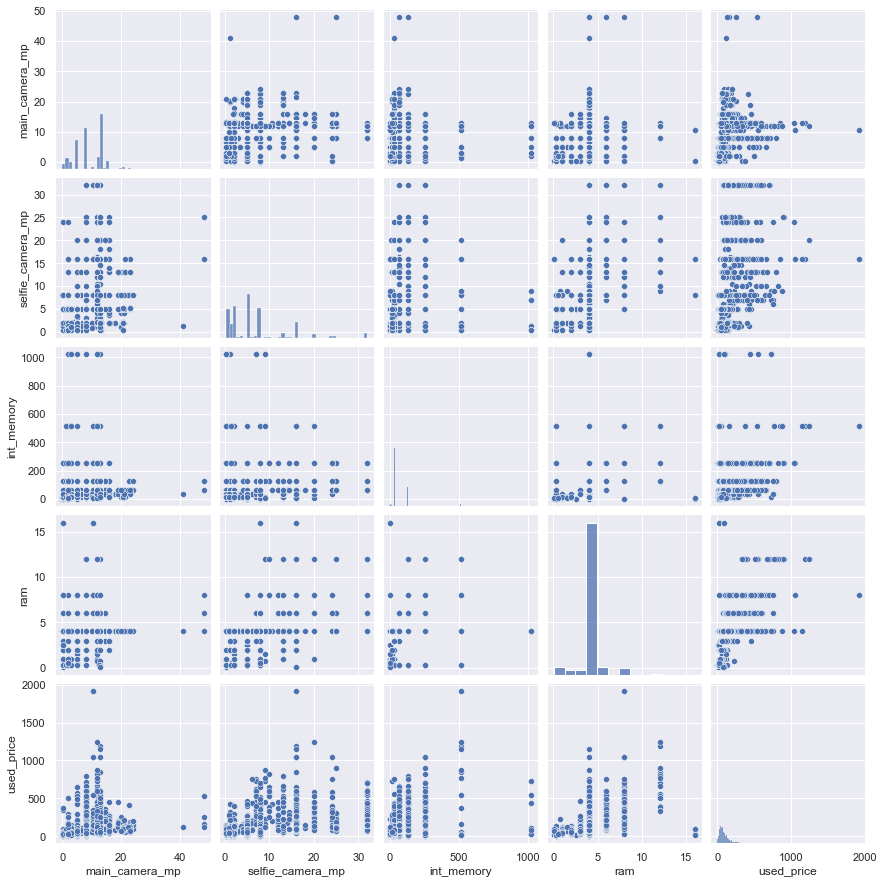

```python
sns.pairplot(data[poss_Multicollinearity]);
```

- main_camera_mp Vs used_price and selfie_camera_mp Vs used_price may have Multicollinearity.
- int_memory Vs used_price and ram Vs used_price may have Multicollinearity.

```python
five_cols = ['screen_size', 'main_camera_mp', 'selfie_camera_mp', 'int_memory',
       'ram', 'used_price']
```

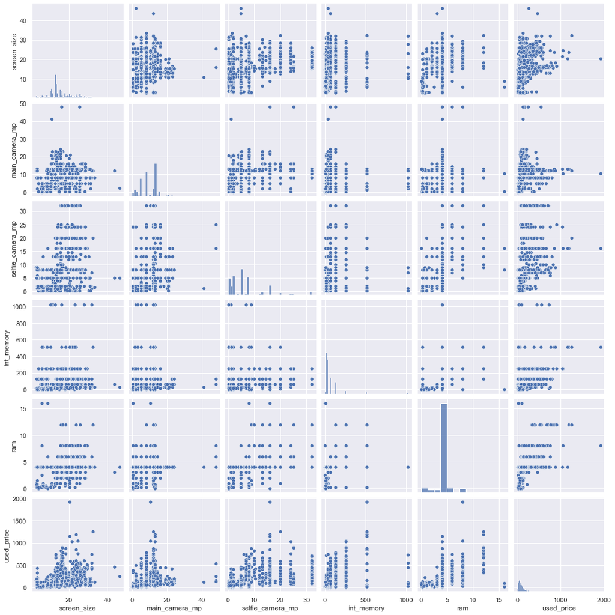

```python
sns.pairplot(data[five_cols]);
```

```python
next_five_cols = ['battery', 'weight', 'release_year', 'days_used', 'new_price',
       'used_price']
```

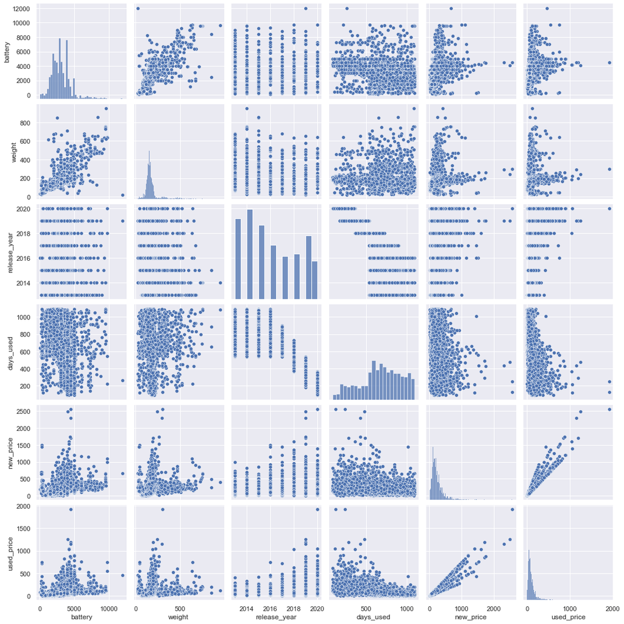

```python
sns.pairplot(data[next_five_cols]);
```

**Observation**

- Battery and weigth are correlated